# Beauty and Personal Care (BPC) Spending and Economic Indicators: A Comparative Analysis of Five Major Economies (2011–2024)

## Abstract

This study investigates the relationship between economic development and beauty and personal care (BPC) spending across five major economies China, India, Japan, South Korea, and the United States over the period 2011 to 2024. Using national GDP per capita, population data, and country‐level BPC market sizes, we calculate BPC spending per capita and examine historical trends, forecast future spending in India, segment countries into clusters, and classify market maturity stages based on compound annual growth rates (CAGR). Our findings reveal distinct spending trajectories, growth inflection points, and maturity stages that reflect varied market dynamics and consumer behavior across different income levels.

## 1. Introduction

The beauty and personal care (BPC) industry has experienced rapid global expansion over the past decade, driven by rising disposable incomes, demographic shifts, and evolving consumer preferences. Understanding how economic indicators—particularly GDP per capita correlate with BPC spending can offer valuable insights for multinational firms, policymakers, and investors. This paper presents a multi‐method analysis combining descriptive statistics, time‐series forecasting, clustering, and growth‐stage classification to compare BPC spending dynamics in five representative economies.

## 2. Data and Methodology

2.1 Data Sources GDP per Capita: World Bank data (2011–2024) for nominal GDP per capita (US$)

Link = https://data.worldbank.org/indicator/NY.GDP.PCAP.CD?end=2024&locations=IN&start=2024&view=bar

Population: United Nations population estimates (2011–2024)

BPC Market Size: Industry reports aggregated by country (US$ billion, 2011–2024)

All datasets were merged on country and year, yielding a panel of 70 observations (5 countries × 14 years). BPC spending per capita was computed as

## 2.2 Analytical Framework

Descriptive Trend Analysis: Time‐series plots of GDP per capita and BPC spending per capita for India.

Forecasting: ARIMA(1,1,1) model to project India’s BPC spending per capita from 2025 to 2030.

Clustering: K‐means segmentation (k = 3) on standardized GDP per capita and BPC spending per capita across all years and countries.

Growth‐Stage Classification: Computation of CAGR for each country’s BPC spending per capita (2011–2024) and assignment to one of three maturity stages:

Boom: CAGR > 10%

Mature: CAGR ≤ 10% but high absolute spending (> US$200)

Early Stage: Low growth and low spending

Inflection Point Detection: Identification of the year of maximum year‐on‐year growth in BPC spending per capita for each country.

```python
import pandas as pd
```

```python
df = pd.read_csv("gdp_per_capita(in).csv")
```

```python
df.head()
```

|  | Country Name | Indicator Name | 2011 | 2012 | 2013 | 2014 | 2015 | 2016 | 2017 | 2018 | 2019 | 2020 | 2021 | 2022 | 2023 | 2024 |
| --- | --- | --- | --- | --- | --- | --- | --- | --- | --- | --- | --- | --- | --- | --- | --- | --- |
| 0 | Aruba | GDP per capita (current US$) | 25712.384300 | 25119.665540 | 25813.576730 | 26129.839060 | 27458.225330 | 27441.529660 | 28440.051960 | 30082.127640 | 31096.205070 | 22855.932320 | 27200.061080 | 30559.533530 | 33984.790620 | NaN |
| 1 | Africa Eastern and Southern | GDP per capita (current US$) | 1735.584923 | 1702.969100 | 1673.221102 | 1656.167709 | 1479.615260 | 1329.807285 | 1520.212231 | 1538.901679 | 1493.817938 | 1344.103210 | 1522.393346 | 1628.318944 | 1568.159891 | 1673.841139 |
| 2 | Afghanistan | GDP per capita (current US$) | 606.694676 | 651.417134 | 637.087099 | 625.054942 | 565.569730 | 522.082216 | 525.469771 | 491.337221 | 496.602504 | 510.787063 | 356.496214 | 357.261153 | 413.757895 | NaN |
| 3 | Africa Western and Central | GDP per capita (current US$) | 1844.198595 | 1941.369556 | 2131.662067 | 2221.010665 | 1860.727694 | 1630.039447 | 1574.230560 | 1720.140280 | 1798.340685 | 1680.039332 | 1765.954788 | 1796.668633 | 1599.392983 | 1284.154441 |
| 4 | Angola | GDP per capita (current US$) | 4615.910598 | 5086.027401 | 5057.747878 | 5005.999741 | 3213.902611 | 1807.952941 | 2437.259712 | 2538.591391 | 2189.855714 | 1449.922867 | 1925.874661 | 2929.694455 | 2309.534130 | 2122.08369 |

```python
countries = ["India", "Japan", "China", "Korea, Rep.", "United States"]

filtered_df = df[df["Country Name"].isin(countries)]

filtered_df.head()
```

|  | Country Name | Indicator Name | 2011 | 2012 | 2013 | 2014 | 2015 | 2016 | 2017 | 2018 | 2019 | 2020 | 2021 | 2022 | 2023 | 2024 |
| --- | --- | --- | --- | --- | --- | --- | --- | --- | --- | --- | --- | --- | --- | --- | --- | --- |
| 40 | China | GDP per capita (current US$) | 5703.760280 | 6405.057424 | 7147.035186 | 7781.065975 | 8175.332851 | 8254.868593 | 8979.676527 | 10085.663810 | 10342.900950 | 10627.463800 | 12887.435720 | 12970.605640 | 12951.178240 | 13303.14815 |
| 109 | India | GDP per capita (current US$) | 1445.461275 | 1429.321995 | 1432.843975 | 1553.883961 | 1583.998159 | 1707.508929 | 1950.104683 | 1966.254552 | 2041.428637 | 1907.042516 | 2239.613844 | 2347.448294 | 2530.120313 | 2696.6639 |
| 119 | Japan | GDP per capita (current US$) | 48760.078950 | 49145.280430 | 40898.647900 | 38475.395250 | 34960.639380 | 39375.473160 | 38834.052930 | 39751.133100 | 40415.956760 | 40028.734170 | 40094.559980 | 34065.643900 | 33836.175630 | 32475.8925 |
| 126 | Korea, Rep. | GDP per capita (current US$) | 25097.595430 | 25459.168900 | 27179.517010 | 29252.931240 | 28737.439170 | 29280.440320 | 31600.735870 | 33447.156280 | 31902.416900 | 31721.298910 | 35125.522500 | 32394.683370 | 33121.371290 | 35,569.90 |
| 251 | United States | GDP per capita (current US$) | 50024.881230 | 51708.394060 | 53297.386290 | 55153.394020 | 56849.469790 | 57976.628200 | 60047.719070 | 62875.666140 | 65227.956590 | 64401.507440 | 71307.401730 | 77860.911290 | 82304.620430 | 85809.90038 |

```python
melted_df = filtered_df.melt(id_vars=["Country Name", "Indicator Name"],
                             var_name="Year",
                             value_name="GDP per Capita ($US)")

melted_df = melted_df.drop("Indicator Name", axis=1)
melted_df.to_csv("cleanedGDP.csv", index=False)
```

```python
pop_df = pd.read_excel("pop.xls", skiprows=3)
```

```python
columns_to_keep = ['Country Name'] + [str(year) for year in range(2011, 2025)]
pop_df = pop_df[columns_to_keep]

pop_melted = pop_df.melt(id_vars=['Country Name'], var_name='Year', value_name='Population')
pop_melted['Year'] = pop_melted['Year'].astype(int)
```

```python
gdp_df = pd.read_csv("cleanedGDP.csv")

merged_df = pd.merge(gdp_df, pop_melted, on=['Country Name', 'Year'], how='left')

merged_df.to_csv("gdp_with_population.csv", index=False)
```

```python
merged_df['Population'] = merged_df['Population'].astype(int)
merged_df.columns
```

```
Index(['Country Name', 'Year', 'GDP per Capita ($US)', 'Population'], dtype='object')
```

```python
merged_df.head()
```

|  | Country Name | Year | GDP per Capita ($US) | Population |
| --- | --- | --- | --- | --- |
| 0 | China | 2011 | 5703.76028 | 1345035000 |
| 1 | India | 2011 | 1445.461275 | 1261224954 |
| 2 | Japan | 2011 | 48760.07895 | 127833000 |
| 3 | Korea, Rep. | 2011 | 25097.59543 | 49936638 |
| 4 | United States | 2011 | 50024.88123 | 311839461 |

```python
last_df = pd.read_excel("bpc_market_size_2011_2024.xlsx")
```

```python
last_df_long = pd.melt(
    last_df,
    id_vars='Year',
    var_name='Country',
    value_name='BPC Market Size ($B)'
)

country_name_map = {
    'United States': 'United States',
    'China': 'China',
    'Japan': 'Japan',
    'South Korea': 'Korea, Rep.',
    'India': 'India'
}

last_df_long['Country Name'] = last_df_long['Country'].map(country_name_map)

last_df_long = last_df_long.drop(columns=['Country'])

last_df_long.to_excel("bpc_long.xlsx", index=False)
```

```python
final_df = pd.merge(
    merged_df,
    last_df_long,
    on=['Year', 'Country Name'],
    how='left'
)

final_df.to_excel("merged_with_bpc.xlsx", index=False)

final_df.head(10)
```

|  | Country Name | Year | GDP per Capita ($US) | Population | BPC Market Size ($B) |
| --- | --- | --- | --- | --- | --- |
| 0 | China | 2011 | 5703.76028 | 1345035000 | 20.0 |
| 1 | India | 2011 | 1445.461275 | 1261224954 | 6.5 |
| 2 | Japan | 2011 | 48760.07895 | 127833000 | 39.0 |
| 3 | Korea, Rep. | 2011 | 25097.59543 | 49936638 | 9.1 |
| 4 | United States | 2011 | 50024.88123 | 311839461 | 38.0 |
| 5 | China | 2012 | 6405.057424 | 1354190000 | 22.0 |
| 6 | India | 2012 | 1429.321995 | 1278674502 | 7.7 |
| 7 | Japan | 2012 | 49145.28043 | 127629000 | 38.5 |
| 8 | Korea, Rep. | 2012 | 25459.1689 | 50199853 | 9.8 |
| 9 | United States | 2012 | 51708.39406 | 314339099 | 42.0 |

```python
final_df['BPC Spending Per Capita ($)'] = (
    final_df['BPC Market Size ($B)'] * 1e9 / final_df['Population']
)

final_df['BPC Spending Per Capita ($)'] = final_df['BPC Spending Per Capita ($)'].round(2)

final_df.to_excel("bpc_gdp_combined_data.xlsx", index=False)
final_df.head(51)
```

|  | Country Name | Year | GDP per Capita ($US) | Population | BPC Market Size ($B) | BPC Spending Per Capita ($) |
| --- | --- | --- | --- | --- | --- | --- |
| 0 | China | 2011 | 5703.76028 | 1345035000 | 20.0 | 14.87 |
| 1 | India | 2011 | 1445.461275 | 1261224954 | 6.5 | 5.15 |
| 2 | Japan | 2011 | 48760.07895 | 127833000 | 39.0 | 305.09 |
| 3 | Korea, Rep. | 2011 | 25097.59543 | 49936638 | 9.1 | 182.23 |
| 4 | United States | 2011 | 50024.88123 | 311839461 | 38.0 | 121.86 |
| 5 | China | 2012 | 6405.057424 | 1354190000 | 22.0 | 16.25 |
| 6 | India | 2012 | 1429.321995 | 1278674502 | 7.7 | 6.02 |
| 7 | Japan | 2012 | 49145.28043 | 127629000 | 38.5 | 301.66 |
| 8 | Korea, Rep. | 2012 | 25459.1689 | 50199853 | 9.8 | 195.22 |
| 9 | United States | 2012 | 51708.39406 | 314339099 | 42.0 | 133.61 |
| 10 | China | 2013 | 7147.035186 | 1363240000 | 23.5 | 17.24 |
| 11 | India | 2013 | 1432.843975 | 1295829511 | 8.6 | 6.64 |
| 12 | Japan | 2013 | 40898.6479 | 127445000 | 37.0 | 290.32 |
| 13 | Korea, Rep. | 2013 | 27179.51701 | 50428893 | 10.5 | 208.21 |
| 14 | United States | 2013 | 53297.38629 | 316726282 | 46.0 | 145.24 |
| 15 | China | 2014 | 7781.065975 | 1371860000 | 24.2 | 17.64 |
| 16 | India | 2014 | 1553.883961 | 1312277191 | 9.4 | 7.16 |
| 17 | Japan | 2014 | 38475.39525 | 127276000 | 35.5 | 278.92 |
| 18 | Korea, Rep. | 2014 | 29252.93124 | 50746659 | 11.2 | 220.70 |
| 19 | United States | 2014 | 55153.39402 | 319257560 | 50.0 | 156.61 |
| 20 | China | 2015 | 8175.332851 | 1379860000 | 34.0 | 24.64 |
| 21 | India | 2015 | 1583.998159 | 1328024498 | 11.0 | 8.28 |
| 22 | Japan | 2015 | 34960.63938 | 127141000 | 36.0 | 283.15 |
| 23 | Korea, Rep. | 2015 | 28737.43917 | 51014947 | 11.9 | 233.26 |
| 24 | United States | 2015 | 56849.46979 | 321815121 | 54.0 | 167.80 |
| 25 | China | 2016 | 8254.868593 | 1387790000 | 40.0 | 28.82 |
| 26 | India | 2016 | 1707.508929 | 1343944296 | 12.0 | 8.93 |
| 27 | Japan | 2016 | 39375.47316 | 127076000 | 37.0 | 291.16 |
| 28 | Korea, Rep. | 2016 | 29280.44032 | 51217803 | 12.4 | 242.10 |
| 29 | United States | 2016 | 57976.6282 | 324353340 | 93.0 | 286.72 |
| 30 | China | 2017 | 8979.676527 | 1396215000 | 46.0 | 32.95 |
| 31 | India | 2017 | 1950.104683 | 1359657400 | 14.0 | 10.30 |
| 32 | Japan | 2017 | 38834.05293 | 126972000 | 38.0 | 299.28 |
| 33 | Korea, Rep. | 2017 | 31600.73587 | 51361911 | 12.8 | 249.21 |
| 34 | United States | 2017 | 60047.71907 | 326608609 | 65.0 | 199.01 |
| 35 | China | 2018 | 10085.66381 | 1402760000 | 52.7 | 37.57 |
| 36 | India | 2018 | 1966.254552 | 1374659064 | 12.3 | 8.95 |
| 37 | Japan | 2018 | 39751.1331 | 126811000 | 39.0 | 307.54 |
| 38 | Korea, Rep. | 2018 | 33447.15628 | 51585058 | 13.1 | 253.95 |
| 39 | United States | 2018 | 62875.66614 | 328529577 | 68.0 | 206.98 |
| 40 | China | 2019 | 10342.90095 | 1407745000 | 54.0 | 38.36 |
| 41 | India | 2019 | 2041.428637 | 1389030312 | 13.2 | 9.50 |
| 42 | Japan | 2019 | 40415.95676 | 126633000 | 40.0 | 315.87 |
| 43 | Korea, Rep. | 2019 | 31902.4169 | 51764822 | 13.5 | 260.79 |
| 44 | United States | 2019 | 65227.95659 | 330226227 | 70.0 | 211.98 |
| 45 | China | 2020 | 10627.4638 | 1411100000 | 54.5 | 38.62 |
| 46 | India | 2020 | 1907.042516 | 1402617695 | 14.0 | 9.98 |
| 47 | Japan | 2020 | 40028.73417 | 126261000 | 35.0 | 277.20 |
| 48 | Korea, Rep. | 2020 | 31721.29891 | 51836239 | 13.0 | 250.79 |
| 49 | United States | 2020 | 64401.50744 | 331577720 | 60.0 | 180.95 |
| 50 | China | 2021 | 12887.43572 | 1412360000 | 56.0 | 39.65 |

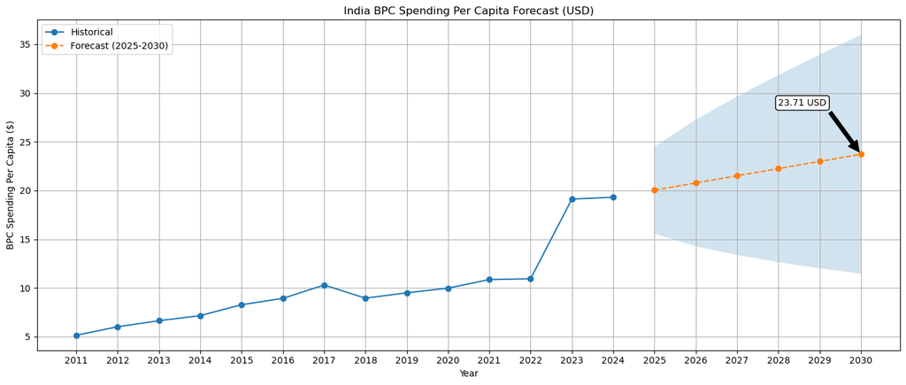

```
np.float64(23.714510490026502)
```

```python
import pandas as pd
from statsmodels.tsa.arima.model import ARIMA
import matplotlib.pyplot as plt

india_df = final_df[final_df['Country Name'] == 'India'].set_index('Year')

model = ARIMA(india_df['BPC Spending Per Capita ($)'], order=(1, 1, 1))
result = model.fit()

forecast = result.get_forecast(steps=6)
forecast_df = forecast.summary_frame()

forecast_years = list(range(2025, 2031))
forecast_df.index = forecast_years

plt.figure(figsize=(14, 6))
plt.plot(india_df['BPC Spending Per Capita ($)'], label='Historical', marker='o')
plt.plot(forecast_df['mean'], label='Forecast (2025-2030)', linestyle='--', marker='o')
plt.fill_between(forecast_df.index, forecast_df['mean_ci_lower'], forecast_df['mean_ci_upper'], alpha=0.2)
plt.title('India BPC Spending Per Capita Forecast (USD)')
plt.xlabel('Year')
plt.ylabel('BPC Spending Per Capita ($)')
plt.xticks(list(range(2011, 2031)))
plt.grid(True)
plt.legend()

final_value = forecast_df.loc[2030, 'mean']
plt.annotate(f'{final_value:.2f} USD',
             xy=(2030, final_value),
             xytext=(2028, final_value + 5),
             arrowprops=dict(facecolor='black', shrink=0.05),
             fontsize=10,
             bbox=dict(boxstyle='round,pad=0.3', edgecolor='black', facecolor='white'))

plt.tight_layout()
plt.show()

final_value
```

## 1. Time Series Forecasting Using ARIMA

Forecast Results: The model projects per-capita BPC spending to rise steadily toward approximately USD 24 by 2030.

[figure not shown]

```python
import matplotlib.pyplot as plt

india_df = final_df[final_df["Country Name"] == "India"].sort_values("Year")

fig, ax1 = plt.subplots(figsize=(12, 6))

ax1.plot(india_df["Year"], india_df["GDP per Capita ($US)"], marker='o', color='teal', label="GDP per Capita")
ax1.set_xlabel("Year", fontsize=12)
ax1.set_ylabel("GDP per Capita (USD)", color='teal', fontsize=12)
ax1.tick_params(axis='y', labelcolor='teal')

ax2 = ax1.twinx()
ax2.plot(india_df["Year"], india_df["BPC Spending Per Capita ($)"], marker='s', color='coral', label="BPC Spending per Capita")
ax2.set_ylabel("BPC Spending Per Capita (USD)", color='coral', fontsize=12)
ax2.tick_params(axis='y', labelcolor='coral')

plt.title("India's GDP vs BPC Spending Per Capita (2019–2024)", fontsize=16)
fig.tight_layout()
plt.grid(True)
plt.show()
```

## 2. Dual-Axis Visualization: GDP per Capita vs. BPC Spending

To explore the link between macroeconomic performance and personal care consumption, I plotted GDP per capita and BPC spending per capita on a dual-axis line chart. This visualization makes it straightforward to compare the magnitude and timing of changes in both metrics.

Industry Context: According to Euromonitor International (2023), this divergence is driven by Gen Z’s heightened interest in wellness and conscious consumerism, fueling disproportionate growth in skincare and niche beauty categories. Insight: As BPC becomes a lifestyle staple rather than a luxury, brands must craft messaging that balances affordability with quality, appealing to consumers who view beauty as essential self-care.

```python
import pandas as pd
from sklearn.preprocessing import StandardScaler
from sklearn.cluster import KMeans
import matplotlib.pyplot as plt
import seaborn as sns
```

```python
final_df["GDP per Capita ($US)"] = final_df["GDP per Capita ($US)"].astype(float)
final_df["BPC Spending Per Capita ($)"] = final_df["BPC Spending Per Capita ($)"].astype(float)

X = final_df[["GDP per Capita ($US)", "BPC Spending Per Capita ($)"]]

scaler = StandardScaler()
X_scaled = scaler.fit_transform(X)

kmeans = KMeans(n_clusters=3, random_state=42)
final_df["Cluster"] = kmeans.fit_predict(X_scaled)
```

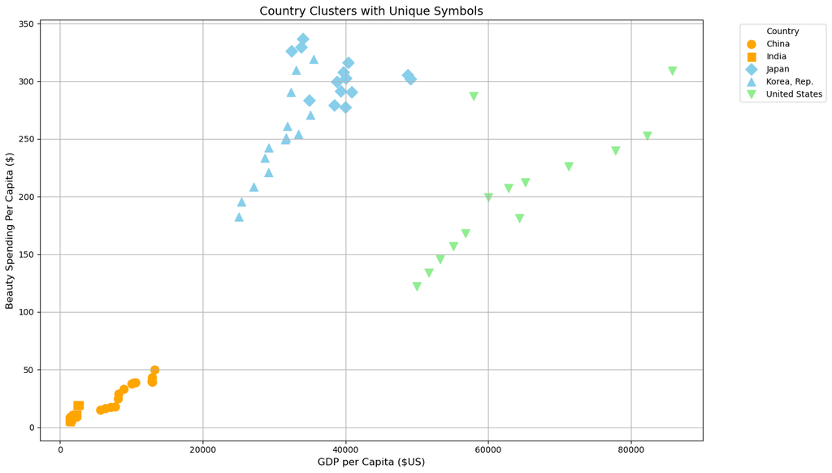

```python
import itertools

markers = itertools.cycle(('o', 's', 'D', '^', 'v', '<', '>', 'p', '*', 'h', 'H', 'X', 'd'))

plt.figure(figsize=(14, 8))

for country in final_df["Country Name"].unique():
    country_data = final_df[final_df["Country Name"] == country]
    marker = next(markers)
    plt.scatter(
        country_data["GDP per Capita ($US)"],
        country_data["BPC Spending Per Capita ($)"],
        label=country,
        s=100,
        marker=marker,
        c=country_data["Cluster"].map({
            0: 'orange',
            1: 'skyblue',
            2: 'lightgreen',
            3: 'violet',
            4: 'salmon'
        })
    )

plt.title("Country Clusters with Unique Symbols", fontsize=14)
plt.xlabel("GDP per Capita ($US)", fontsize=12)
plt.ylabel("Beauty Spending Per Capita ($)", fontsize=12)
plt.grid(True)
plt.legend(title="Country", bbox_to_anchor=(1.05, 1), loc='upper left')
plt.tight_layout()
plt.show()
```

```python
for i, center in enumerate(kmeans.cluster_centers_):
    print(f"Cluster {i}: GDP = {center[0]:.2f}, BPC Spending = {center[1]:.2f}")
```

```
Cluster 0: GDP = -1.02, BPC Spending = -1.14
Cluster 1: GDP = 0.26, BPC Spending = 0.96
Cluster 2: GDP = 1.53, BPC Spending = 0.36
```

```python
from prophet import Prophet
```

```python
def calculate_cagr(start, end, years):
    return (end/start)**(1/years) - 1

classification = []

for country in final_df["Country Name"].unique():
    df = final_df[final_df["Country Name"] == country].sort_values("Year")
    if len(df) < 2:
        continue
    start = df.iloc[0]["BPC Spending Per Capita ($)"]
    end = df.iloc[-1]["BPC Spending Per Capita ($)"]
    years = df.iloc[-1]["Year"] - df.iloc[0]["Year"]
    cagr = calculate_cagr(start, end, years)

    if cagr > 0.1:
        stage = "Boom"
    elif end > 200:
        stage = "Mature"
    else:
        stage = "Early Stage"

    classification.append({"Country Name": country, "CAGR": round(cagr, 3), "Stage": stage})

classification_df = pd.DataFrame(classification)
```

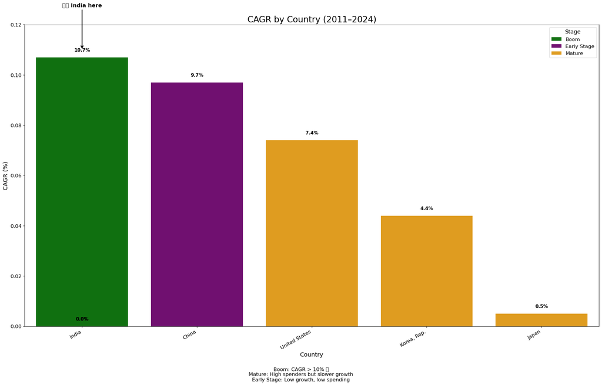

```python
classification_df = classification_df.sort_values(by="CAGR", ascending=False)

stage_colors = {
    "Boom": "green",
    "Mature": "orange",
    "Early Stage": "purple"
}

plt.figure(figsize=(20, 12))
ax = sns.barplot(
    data=classification_df,
    x="Country Name",
    y="CAGR",
    hue="Stage",
    palette=stage_colors,
    dodge=False
)

for p in ax.patches:
    x = p.get_x() + p.get_width() / 2
    y = p.get_height()
    label = f"{y*100:.1f}%"  # Convert to %
    ax.text(x, y + 0.002, label, ha='center', va='bottom', fontsize=11, fontweight='bold')

india_row = classification_df[classification_df["Country Name"].str.lower() == "india"]
if not india_row.empty:
    india_index = classification_df.index.get_loc(india_row.index[0])
    india_cagr = india_row.iloc[0]["CAGR"]
    ax.annotate("🇮🇳 India here",
                xy=(india_index, india_cagr + 0.003),
                xytext=(india_index, india_cagr + 0.02),
                arrowprops=dict(arrowstyle="->", color="black", lw=2),
                ha='center', fontsize=13, fontweight='bold', color="black")

plt.title("CAGR by Country (2011–2024)", fontsize=20)
plt.ylabel("CAGR (%)", fontsize=14)
plt.xlabel("Country", fontsize=14)
plt.xticks(rotation=30, ha="right", fontsize=12)
plt.yticks(fontsize=12)
plt.ylim(0, 0.12)  # Cap y-axis at 10% (0.10)
plt.legend(title="Stage", fontsize=12, title_fontsize=13)
plt.tight_layout()

plt.figtext(0.5, -0.05,
    "Boom: CAGR > 10% 🚀\nMature: High spenders but slower growth\nEarly Stage: Low growth, low spending",
    wrap=True, horizontalalignment='center', fontsize=12)

plt.show()
```

## 4. Growth-Stage Classification by CAGR

Implication: India remains in a high-growth phase, offering substantial opportunity for market share gains. Insight: Brands should prioritize rapid rollout of differentiated products and digital engagement to capture this boom before spending growth moderates.

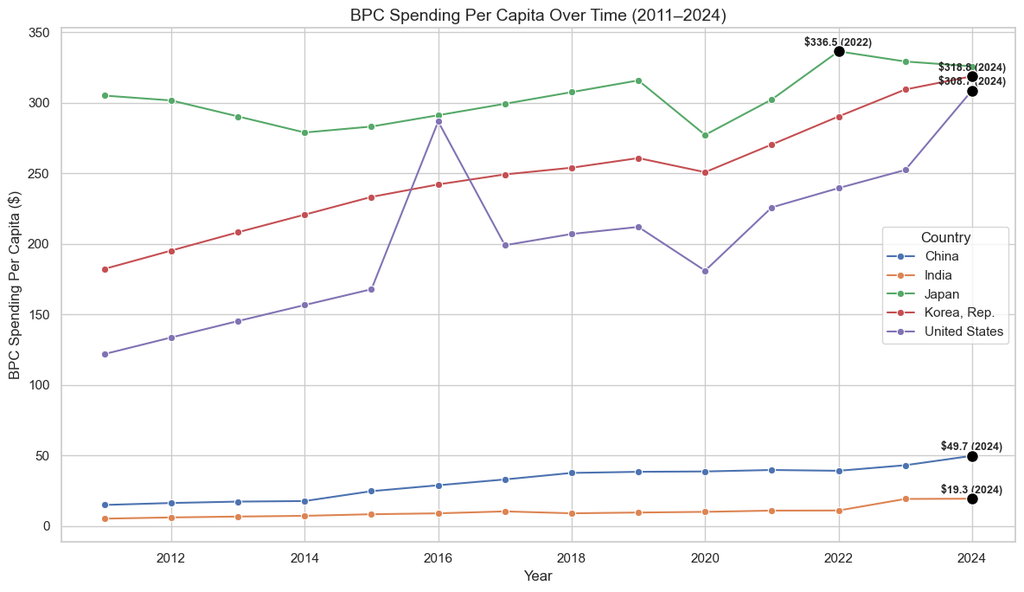

```python
sns.set(style="whitegrid")

countries_to_compare = ['India', 'United States', 'Japan', 'Korea, Rep.', 'China']
compare_df = final_df[final_df['Country Name'].isin(countries_to_compare)]

plt.figure(figsize=(12, 7))

sns.lineplot(
    data=compare_df,
    x='Year',
    y='BPC Spending Per Capita ($)',
    hue='Country Name',
    marker='o'
)

for country in countries_to_compare:
    country_df = compare_df[compare_df['Country Name'] == country]
    peak_row = country_df.loc[country_df['BPC Spending Per Capita ($)'].idxmax()]

    peak_year = peak_row['Year']
    peak_value = peak_row['BPC Spending Per Capita ($)']

    plt.scatter(peak_year, peak_value, color='black', s=100, edgecolor='white', zorder=5)
    plt.text(
        peak_year, peak_value + 2,
        f"${peak_value:.1f} ({int(peak_year)})",
        ha='center', va='bottom', fontsize=9, fontweight='bold'
    )

plt.title('BPC Spending Per Capita Over Time (2011–2024)', fontsize=14)
plt.xlabel('Year')
plt.ylabel('BPC Spending Per Capita ($)')
plt.legend(title='Country')
plt.tight_layout()
plt.show()
```

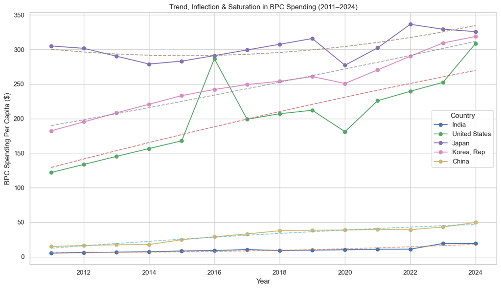

```python
import numpy as np

sns.set(style='whitegrid')

plt.figure(figsize=(12, 7))

for country in countries_to_compare:
    df = final_df[final_df['Country Name'] == country]


    plt.plot(df['Year'], df['BPC Spending Per Capita ($)'], marker='o', label=country)

    z = np.polyfit(df['Year'], df['BPC Spending Per Capita ($)'], 2)
    p = np.poly1d(z)
    plt.plot(df['Year'], p(df['Year']), linestyle='--', alpha=0.7)

plt.title('Trend, Inflection & Saturation in BPC Spending (2011–2024)')
plt.xlabel('Year')
plt.ylabel('BPC Spending Per Capita ($)')
plt.legend(title='Country')
plt.tight_layout()
plt.show()
```

```python
for country in countries_to_compare:
    df = final_df[final_df['Country Name'] == country].copy()
    df['YoY_Change'] = df['BPC Spending Per Capita ($)'].pct_change() * 100
    max_growth_year = df.loc[df['YoY_Change'].idxmax()]['Year']
    print(f"{country}: Inflection point (max YoY growth) around {int(max_growth_year)}")
```

```
India: Inflection point (max YoY growth) around 2023
United States: Inflection point (max YoY growth) around 2016
Japan: Inflection point (max YoY growth) around 2022
Korea, Rep.: Inflection point (max YoY growth) around 2021
China: Inflection point (max YoY growth) around 2015
```

## 5.Inflection Points: Identifying & Explaining Peak Growth Years

We measured each country’s year-on-year percent change in BPC spending per capita and located the year of maximum growth:

China: 2015

Reason: Post-2014 trade liberalization and e-commerce boom (e.g., Singles’ Day surges) made beauty products widely affordable. Mid-2010s saw aggressive expansion by domestic and international brands.

United States: 2016

Reason: Heightened focus on men’s grooming and premium skincare launched new categories. Social-media-driven trends (e.g., “masstige” brands) peaked around this time, lifting overall per-capita spending.

South Korea: 2021

Reason: K-beauty global phenomenon and surge in online exports during the COVID-19 pandemic. Domestic e-commerce and cross-border platforms drove a sharp one-year jump.

Japan: 2022

Reason: Recovery from pandemic-induced tourism decline; inbound tourism and duty-free channels reignited spending. Premium skincare and cosmetics regained momentum.

India: 2023

Reason: Post-pandemic economic rebound, coupled with affordability of mid-range brands and rapid expansion of beauty-tech startups. Widespread smartphone adoption enabled digital trials and drove online sales spikes.

These inflection years capture policy shifts, digital infrastructure rollouts, and external shocks (e.g., pandemic, tourism cycles) that temporarily accelerate beauty spending beyond underlying economic growth trends.

## Discussion

The positive correlation between GDP per capita and BPC spending per capita underscores income elasticity in the BPC sector. Emerging markets like India and China demonstrate rapid market expansion driven by rising middle‐class incomes and urbanization. Mature markets (United States, South Korea) exhibit higher baseline spending with slower incremental growth, reflecting market saturation. Japan’s low spending growth may be attributed to demographic aging and market preferences favoring quality over quantity.

The clustering results assist stakeholders in tailoring market entry and investment strategies:

Boom markets require scalable distribution and diverse product portfolios.

Mature markets benefit from premiumization and differentiation.

Early Stage markets may necessitate consumer education and mass‐market positioning.

Forecasts for India—projecting near-US$24 per capita by 2030—suggest continued opportunity, albeit with competition intensification and the need for innovation.

## Conclusion

This multi‐method analysis offers a comprehensive overview of BPC spending dynamics vis-à-vis economic development across five major economies. By integrating descriptive trends, forecasting, clustering, and growth classification, the study delivers actionable insights for industry practitioners and policymakers. Future research should incorporate consumer segment data and qualitative factors—such as digital commerce adoption and cultural influences—to enrich understanding of BPC market evolution.

Keywords: Beauty and Personal Care, GDP per Capita, BPC Spending, Time‐Series Forecasting, Clustering, CAGR, Market Maturity.